# 01_Generate-Split

Junyi Chu

2022-01-12

This notebook generates the train/test split for already annotated videos from the Lookit Physics project (prefphys). Specifically, this generates two tables:

- A **participant table** listing each participant, their train/test assignment, and some demographic information used to make the split (age, sex, race)
- A **video table** listing video sessions (might be multiple per participant) and matched annotation file(s).

This is a work in progress. Work flow:

1. Setup (import files, some checks)
2. Generate dataframe containing information about each participant
3. Conduct sampling procedure to assign participants to train/test, with some manual adjustments as needed
4. Report statistics of participants assigned to train/test.
5. Generate desired output tables and export as csv

The R notebook “02_Move-files-for-QI.Rmd” then copies appropriate video and annotation files into the Dropbox folder for QI engineers.

# Setup

Do some basic R setup, import packages, set random seed.

This notebook takes as input Session data (dates, age, etc) and Participant demographic data (from Lookit). For now, we use original session uuids, lookit user ids, etc. Eventually we want to use deidentified IDs.

Clean and add pilot demographic data

```r
df.pilotkids <- read_tsv("../raw participant data/pilot_participants_data-identifying.tsv") %>%
  rename(uuid=shortId,
         child=child.profileId,
         race_identification = household_race_identification,
         state = state_location) %>%
    mutate(child = ifelse(str_detect(child, '\\.'),
                    str_sub(child,-5,-1),
                    child)) %>%
  rename_with(.fn = ~paste0("parent.", .x),
    .cols=languages_spoken:density) %>%
    mutate(studyid="57bc591dc0d9d70055f775db",
           nsessions_avail=1,
           nsessions_coded=1,
           child.age.min=floor(ageRegistration),
           child.age.max=floor(ageRegistration),
           parent.annual_income = as.character(parent.annual_income),
           # mutate race
           parent.race.NA = parent.race_identification=="[]" | is.na(parent.race_identification),
         parent.race.white=str_detect(parent.race_identification,"white|White"),
         parent.race.asian=str_detect(parent.race_identification,"asian|Asian"),
         parent.race.black=str_detect(parent.race_identification,"black|Black"),
         parent.race.hispanic=str_detect(parent.race_identification,"hisp|Hisp"),
         parent.race.mideastnaf=str_detect(parent.race_identification,"Middle|mideast"),
         parent.race.hpi=str_detect(parent.race_identification, "hawaiian|Hawaiian"),
         parent.race.native=str_detect(parent.race_identification, "native"),
         parent.race.other=str_detect(parent.race_identification, "other")) %>%
  mutate(parent.race.nonwhite=ifelse(parent.race.NA, NA,
                                  parent.race.asian|parent.race.black|
                                  parent.race.hispanic|parent.race.mideastnaf|
                                    parent.race.hpi|parent.race.native|parent.race.other))

# Combine!
common_cols <- intersect(colnames(df.kids_demo), colnames(df.pilotkids))

df.demo <- bind_rows(
  df.kids_demo, # keep all
  df.pilotkids[common_cols]
)
```

Clean and add pilot session data

```r
# Add PILOT to session metadata & child demographic data
#
df.sessions.pilot <- read_csv("../raw participant data/pilot_trials_data.csv") %>%
  select(uuid=shortId,
         child=child.profileId,
         child.gender,
         child.ageSession=ageRegistration,
         consentnotes, usable,
         privacy.exit=exit.survey.useOfMedia,
         privacy.databrary = exit.survey.databraryShare,
         video.nVideosExpected = nVideosExpected,
         video.nVideosFound = nVideosFound,
         video.expectedDuration = expectedDuration,
         video.actualDuration = actualDuration,
         starts_with("mood.survey")) %>%
  unique() %>%
  rename_with(~str_replace(., "mood.survey.", "mood.")) %>%
  rename(mood.minsToNextNap = mood.nextNap,
         mood.minsSincePrevNap = mood.napWakeUp) %>%
  mutate(
    child.ageSessionRounded = floor(child.ageSession),
    studyid = "57bc591dc0d9d70055f775db",
    child = str_sub(child,-5,-1),
    child.gender = tolower(substr(child.gender, 1, 1)),
    video.privacy = case_when(
      is.na(privacy.exit) ~ "private.local",
      privacy.exit == "private" &
        privacy.databrary == "yes" ~ "private.databrary",
      privacy.exit == "private" &
        privacy.databrary == "no" ~ "private.local",
      privacy.exit == "scientific" &
        privacy.databrary == "yes" ~ "scientific.databrary",
      privacy.exit == "scientific" &
        privacy.databrary == "no" ~ "scientific.local",
      privacy.exit == "public" &
        privacy.databrary == "yes" ~ "public.databrary",
      privacy.exit == "public" &
        privacy.databrary == "no" ~ "public.local"
    )
  )

# Combine! Ignore non-shareable
df.sessions <- bind_rows(df.sessions, df.sessions.pilot) %>%
  filter(privacy.exit != "private")
```

Remove unnecessary tables

```r
rm(df.kids_demo, df.pilotkids, df.sessions.pilot, common_cols)
```

### Check missing

# Participant dataframe

So generate the list of children we care about for icatcher purposes, which is we have demographic data, and video

### Participant breakdown by study version:

```r
# video, there are 10 from pilot study that arenw
df.videos.use %>% count(childID, studyID) %>% count(studyID)
```

|  | studyID | n |
| --- | --- | --- |
| 1 | 57bc591dc0d9d70055f775db | 26 |
| 2 | 583c892ec0d9d70082123d94 | 20 |
| 3 | cfddb63f-12e9-4e62-abd1-47534d6c4dd2 | 115 |

```r
# shareable sessions
df.sessions.use %>% count(child, studyid) %>% count(studyid)
```

|  | studyid | n |
| --- | --- | --- |
| 1 | 57bc591dc0d9d70055f775db | 26 |
| 2 | 583c892ec0d9d70082123d94 | 20 |
| 3 | cfddb63f-12e9-4e62-abd1-47534d6c4dd2 | 115 |

```r
# kids
df.kids.use %>% count(studyID)
```

|  | studyID | n |
| --- | --- | --- |
| 1 | 57bc591dc0d9d70055f775db | 26 |
| 2 | 583c892ec0d9d70082123d94 | 20 |
| 3 | cfddb63f-12e9-4e62-abd1-47534d6c4dd2 | 115 |

```r
df.demo.use %>% count(studyid)
```

|  | studyid | n |
| --- | --- | --- |
| 1 | 57bc591dc0d9d70055f775db | 26 |
| 2 | 583c892ec0d9d70082123d94 | 20 |
| 3 | cfddb63f-12e9-4e62-abd1-47534d6c4dd2 | 115 |

## Participant Table

We want the variables:

- age at session 1 (in months)
- gender (m/f)
- race (nonwhite yes, no, or NA)
- number of sessions / videos available
- number of videos coded
- country

```r
participants <- df.demo.use %>%
  select(studyid, child, child.gender, parent.race.white, parent.race.nonwhite) %>%
  mutate(child.gender = str_sub(child.gender, 1, 1),
         parent.race.nonwhite = factor(parent.race.nonwhite,
                                          levels=c(FALSE, TRUE),
                                          labels=c("white only", "reported non-white"))) %>%
  left_join(df.kids.use, by=c(studyid='studyID', child='childID'))

videos <- df.videos.use %>%
  left_join(df.sessions.use,
            by=c(studyID="studyid", childID="child", videoID="uuid",
                 privacy="privacy.exit")) %>%
  left_join(select(participants, studyid:parent.race.nonwhite),
            by=c(studyID="studyid", childID="child",
                 child.gender='child.gender')) %>%
  rename(video.nTrialsExpected = video.nVideosExpected,
         video.nTrialsFound = video.nVideosFound) %>%
  mutate(n_coders=as.factor(3-is.na(coder1)-is.na(coder2)-is.na(coder3)),
         child.ageSessionRounded = ifelse(child.ageSession < 4, 4, child.ageSessionRounded)) # count the 3.97 month old as 4 months old

participants <-
    videos %>% group_by(childID) %>%
      summarise(child.age.min = min(child.ageSessionRounded),
            child.age.max = max(child.ageSessionRounded)) %>%
      right_join(participants, by=c(childID='child'))

# check consistency between the two tables
sum(participants$n_videos) == nrow(videos)
```

```
## [1] TRUE
```

```r
sum(participants$n_coded) == sum(!is.na(videos$coder1))
```

```
## [1] TRUE
```

```r
sum(participants$n_codedtwice) == sum(!is.na(videos$coder2))
```

```
## [1] TRUE
```

We have 161 children contributing 755 scientific/public level videos. Among these we have already coded 225 once. Among those coded videos, 61 are coded by two humans.

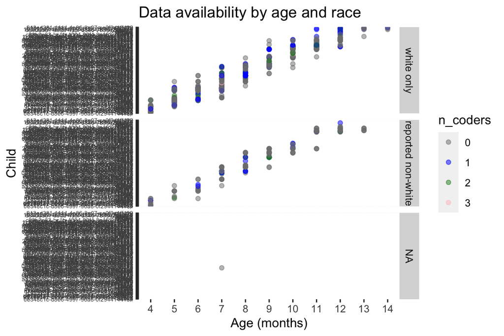

```r
videos %>% # plot
  filter(child.ageSession < 15) %>%
  ggplot(aes(y=reorder(childID, child.ageSessionRounded))) +
  geom_point(aes(x=child.ageSessionRounded, color=n_coders), alpha=0.5) +
  labs(x='Age (months)', y='Child', title='Data availability by age and race') +
  facet_grid(vars(parent.race.nonwhite)) +
  theme(axis.text.y=element_text(size = 5)) +
  scale_x_continuous(breaks=seq(4,14,1))+
  scale_color_manual(values=c("grey50", "blue", "forestgreen", "pink"))
```

## Age

We have some variability by age. The coded set reflects this distribution:

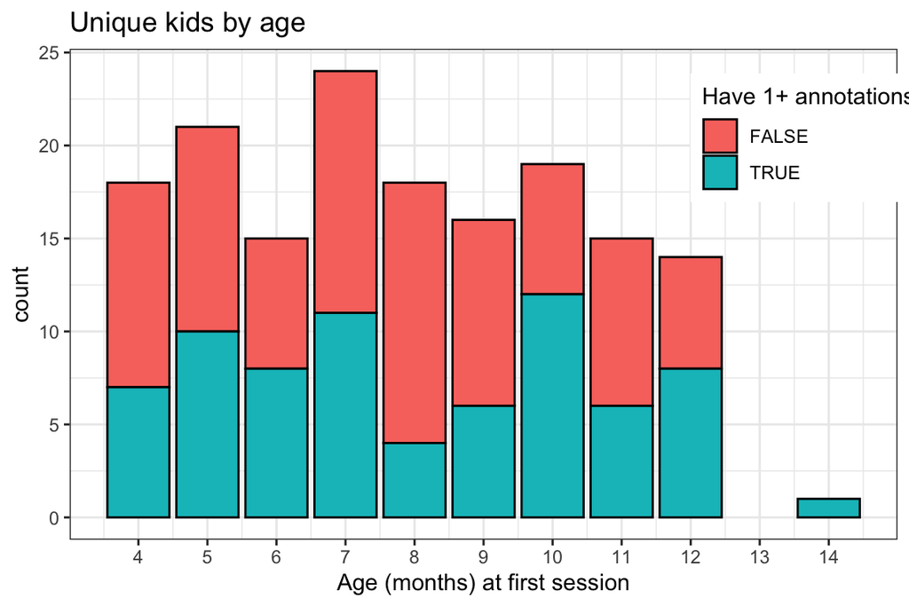

```r
participants %>%
  ggplot() +
  geom_bar(aes(x=child.age.min, fill=n_coded>0),
           color='black') +
  labs(title="Unique kids by age",
       x="Age (months) at first session",
       fill="Have 1+ annotations") +
  theme_bw()+
  theme(legend.position = c(.75, .95),
    legend.justification = c("left", "top")) +
  scale_x_continuous(breaks=seq(4,14,1))
```

Since each child contributes multiple sessions,we can look at overall dataset by session:

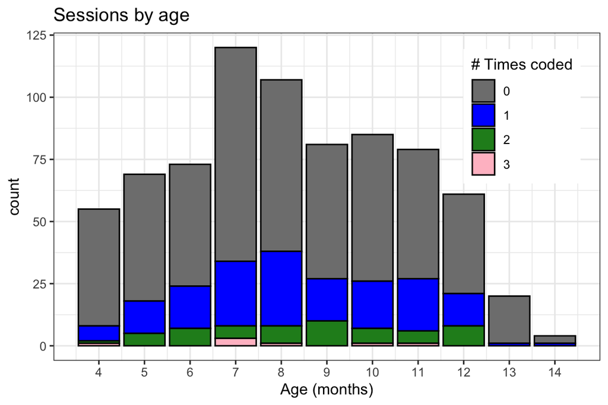

```r
videos %>% filter(child.ageSessionRounded<15) %>%
  arrange(-n_coders) %>%
  ggplot() +
  geom_bar(aes(x=child.ageSessionRounded, fill=as.factor(n_coders)),
           color='black')+
  scale_fill_manual(values=c("grey50", "blue", "forestgreen", "pink")) +
  scale_x_continuous(breaks=seq(4,14,1))+
  labs(title="Sessions by age",
       x="Age (months)",
       fill="# Times coded") +
  theme_bw()+
  theme(legend.position = c(.75, .95),
    legend.justification = c("left", "top"))
```

Relatively speaking,

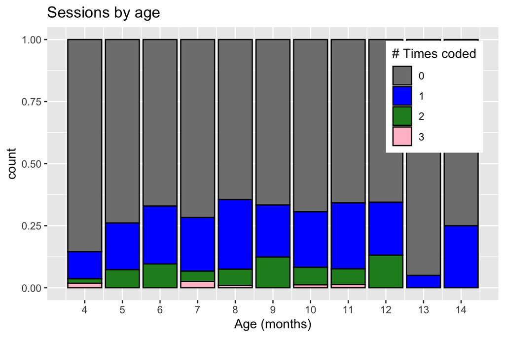

```r
videos %>% filter(child.ageSessionRounded<15) %>%
  arrange(-n_coders) %>%
  ggplot() +
  geom_bar(aes(x=child.ageSessionRounded, fill=as.factor(n_coders)),
           color='black', position = position_fill(),
           width=)+
  scale_fill_manual(values=c("grey50", "blue", "forestgreen", "pink")) +
  scale_x_continuous(breaks=seq(4,14,1))+
  labs(title="Sessions by age",
       x="Age (months)",
       fill="# Times coded") +
  theme(legend.position = c(.75, .95),
    legend.justification = c("left", "top"))
```

## Gender

We have an even mix of gender (male/female), but we could code more females.

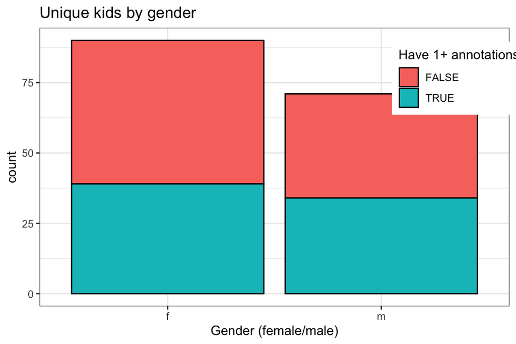

```r
ggplot(participants, aes(x=child.gender, fill=n_coded>0)) +
  geom_bar(aes(x=child.gender, fill=n_coded>0),
           color='black') +
  labs(title="Unique kids by gender",
       x="Gender (female/male)",
       fill="Have 1+ annotations") +
  theme_bw()+
  theme(legend.position = c(.75, .95),
    legend.justification = c("left", "top"))
```

## Race

Participant count by race/ethnicity (white/nonwhite). This was a multi-select checkbox, and we actually have quite a few children who selected multiple options.

```r
addmargins(with(participants, table(parent.race.white, parent.race.nonwhite)))
```

```
##                  parent.race.nonwhite
## parent.race.white white only reported non-white Sum
##             FALSE          0                 15  15
##             TRUE         117                 28 145
##             Sum          117                 43 160
```

```r
addmargins(with(participants,
                table(parent.race.nonwhite,n_coded>0)), 2)
```

```
##
## parent.race.nonwhite FALSE TRUE Sum
##   white only            61   56 117
##   reported non-white    26   17  43
```

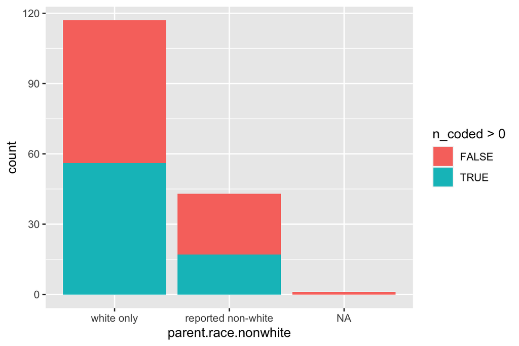

```r
ggplot(participants, aes(x=parent.race.nonwhite, fill=n_coded>0)) +
  geom_bar()
```

# Sampling procedure

```r
participants_ML <- participants %>% filter(n_coded>0) %>%
    mutate(child.age.bin = case_when(
    child.age.min <= 6 ~ "04-06mo",
    child.age.min <= 9 ~ "07-09mo",
    child.age.min <= 14 ~ "10-14mo"
  ))
```

Out of the **already coded**, we need a split for developing technical tools (at minimum, disjoint sets of babies - same babies NOT in both sets). Currently there are 73 unique infants with coded videos, consisting of:

- 25 unique infants from pilot set (each 1 video)
- 48 unique infants in non-pilot, already coded set

## Dataset statistics

- Age (4 to 14 months old, divided into 3 intervals)
- Sex (female / male)
- Race (None or Any reported non-white racial identification)

There are 3x2x2 = 12 subgroups that we want evenly divided into train/test

### Mosaic plot

Graph race, sex and age – we want to split this into even sets.

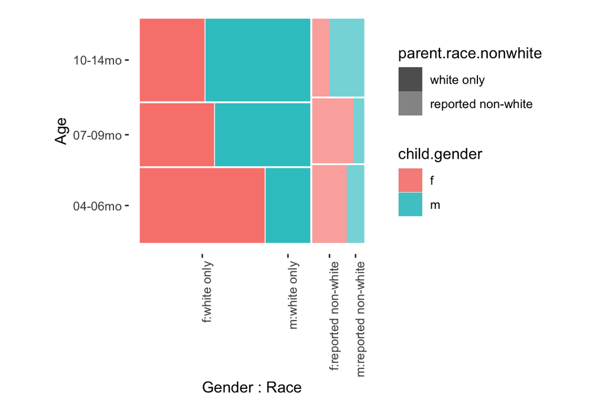

```r
library(ggmosaic)
ggplot(data = participants_ML) +
  #geom_mosaic(aes(x=product(child.age.bin, parent.race.nonwhite),
  #                fill=child.gender)) +
  geom_mosaic(aes(x=product(child.age.bin, parent.race.nonwhite),
                  fill=child.gender,
              alpha=parent.race.nonwhite))+
  scale_alpha_manual(values =c(.9,.6)) +
  labs(x="Gender : Race", y="Age")+
    theme_mosaic()+
  theme(axis.text.x = element_text(angle = 90, hjust = 1))
```

### Race

```r
participants_ML %>%
  count(parent.race.nonwhite) %>%
  mutate(prop = n/sum(n),
         target_n = n*.7)
```

|  | parent.race.nonwhite | n | prop | target_n |
| --- | --- | --- | --- | --- |
| 1 | white only | 56 | 0.7671233 | 39.2 |
| 2 | reported non-white | 17 | 0.2328767 | 11.9 |

### Age

Note that repeat sessions will be older in age, but still within 2 months of first session.

```r
participants_ML %>%
  count(child.age.bin) %>%
  mutate(prop = n/sum(n),
         target_n = n*.7)
```

|  | child.age.bin | n | prop | target_n |
| --- | --- | --- | --- | --- |
| 1 | 04-06mo | 25 | 0.3424658 | 17.5 |
| 2 | 07-09mo | 21 | 0.2876712 | 14.7 |
| 3 | 10-14mo | 27 | 0.3698630 | 18.9 |

### Sex

```r
participants_ML %>%
  count(child.gender) %>%
  mutate(prop = n/sum(n),
         target_n = n*.7)
```

|  | child.gender | n | prop | target_n |
| --- | --- | --- | --- | --- |
| 1 | f | 39 | 0.5342466 | 27.3 |
| 2 | m | 34 | 0.4657534 | 23.8 |

## Generate split

We follow procedure in https://towardsdatascience.com/stratified-sampling-and-how-to-perform-it-in-r-8b753efde1ef

```r
n_training_kids = round(.7*nrow(participants_ML))
n_test_kids = nrow(participants_ML) - n_training_kids
n_validation_kids = round(.2*n_training_kids)
```

We’re targeting 30% for test (n= 22 kids) and 70% for training (n= 51). Training set will be further divided into 20% for validation (10).

### First split into 70/30 train/test

**Manual adjustment**

```r
# Work with a temporary table for manual adjustments
split0 <- participants_ML
table(split0$which.dataset)
```

```
##
## 1_train  2_test
##      51      22
```

```r
## VIEW
select(split0, childID,
                           child.gender,
                           child.age.bin,
                           parent.race.nonwhite,
                           which.dataset) %>%
  arrange(child.age.bin, child.gender, parent.race.nonwhite, which.dataset) %>%
  view()

## MANUAL ADJUSTMENT
split0$which.dataset[split0$childID %in%
                           c("diSip", #4-6mo F w
                             "JTU1W", #4-6mo F w
                             "KMKdO", #4-6mo F nw
                             "1739034f-8632-4216-94a9-4cd336f77f16", #10-14mo M w
                             "3ae67b03-bb6b-4c98-a6e3-55581f4b322b" #7mo
                             )] <- "1_train"

split0$which.dataset[split0$childID %in%
                           c("c409b6f6-6cce-46e2-b1ac-47299ba53a83", #7mo F w
                             "dc0fe583-5648-42b6-8127-679f2e8e6d4f", #7mo M w
                             "4e3e2517-4788-45ae-94cb-1a0dbd22d4d7", # 10-14mo M nw
                             "4b65cc5b-9246-4411-b6af-c1e0de714597", # 10-14mo F nw
                             "95bd8dcc-f844-40ca-b342-6f20d92ccb68" # 10mo F W
                             )] <- "2_test"

participants_ML<- split0
testkids <- participants_ML %>%
  filter(which.dataset=="2_test")
trainkids <- participants_ML %>%
  filter(which.dataset=="1_train")
```

### Split train into train/validate

80/20

**Manual adjustment**

```r
# Work with a temporary table for manual adjustments
split1 <- trainkids %>%
  mutate(which.dataset = ifelse(
    childID %in% generated2$childID, "1_validate", "1_train"
  ))
table(split1$which.dataset)
```

```
##
##    1_train 1_validate
##         41         10
```

```r
## VIEW
select(split1, childID,
                           child.gender,
                           child.age.bin,
                           parent.race.nonwhite,
                           which.dataset) %>%
  arrange(child.age.bin, child.gender, parent.race.nonwhite, which.dataset) %>%
  view()

## MANUAL ADJUSTMENT
split1$which.dataset[split1$childID %in%
                       c("3ae67b03-bb6b-4c98-a6e3-55581f4b322b" # 7m F NW
                         ,"15e60e99-5828-49cf-8367-92281c8cd18c" #7m M W
                         ,"acr9J" #7m M W
                         )
                           ] <- "1_train"

split1$which.dataset[split1$childID %in%
                           c(
                             "X1Fij" #7m F W
                             ,"WIH7v" #4m F NW
                             ,"2089b2e8-c0ec-4e5a-ab2e-74a01b977bd1" #10m M NW
                             ,"Wve6h" #10m M W
                           )] <- "1_validate"

table(split1$which.dataset)
```

```
##
##    1_train 1_validate
##         38         13
```

```r
# Update participants table
validatekids <- split1  %>%
  filter(which.dataset=="1_validate")

participants_ML[participants_ML$childID %in% validatekids$childID, 'which.dataset'] <- "1_validate"
```

# Report splits

### Mosaic Plot

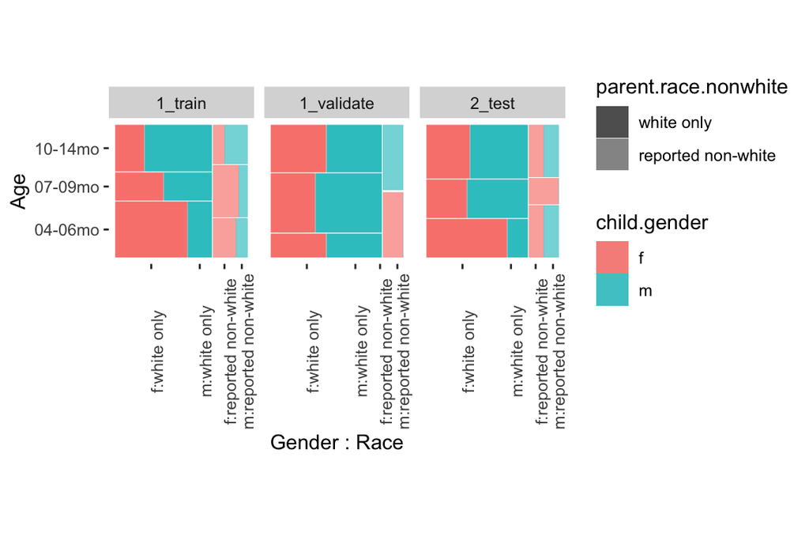

```r
# plot
ggplot(participants_ML) +
  geom_mosaic(aes(x=product(child.age.bin, parent.race.nonwhite),
                  fill=child.gender,
              alpha=parent.race.nonwhite))+
  facet_wrap(.~which.dataset, drop = T)+
  scale_alpha_manual(values =c(.9,.6)) +
  labs(x="Gender : Race", y="Age")+
    theme_mosaic()+
  theme(axis.text.x = element_text(angle = 90))
```

### Race

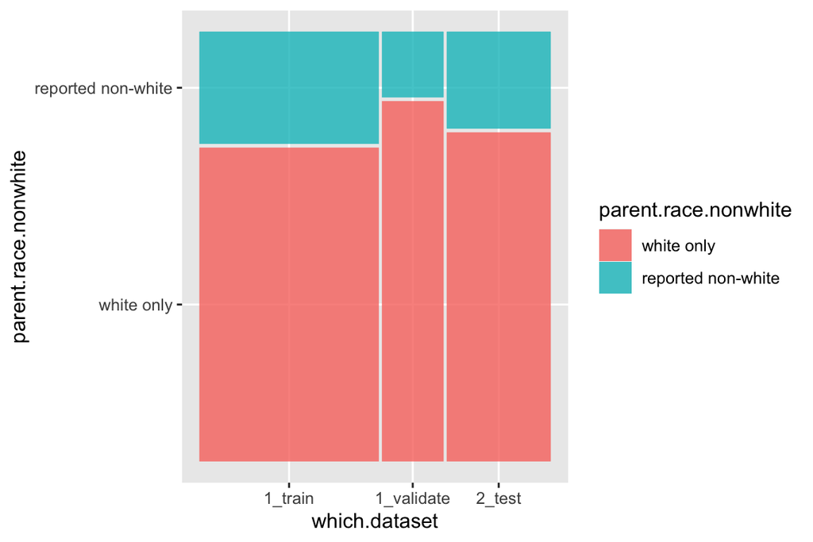

```r
# Plot
ggplot(participants_ML) +
  geom_mosaic(aes(x=product(which.dataset), fill=parent.race.nonwhite))
```

```r
# Counts
with(participants_ML, table(parent.race.nonwhite, which.dataset))
```

```
##                     which.dataset
## parent.race.nonwhite 1_train 1_validate 2_test
##   white only              28         11     17
##   reported non-white      10          2      5
```

```r
# Proportions
with(participants_ML, table(parent.race.nonwhite, which.dataset))%>%
  prop.table(margin=2)
```

```
##                     which.dataset
## parent.race.nonwhite   1_train 1_validate    2_test
##   white only         0.7368421  0.8461538 0.7727273
##   reported non-white 0.2631579  0.1538462 0.2272727
```

### Age

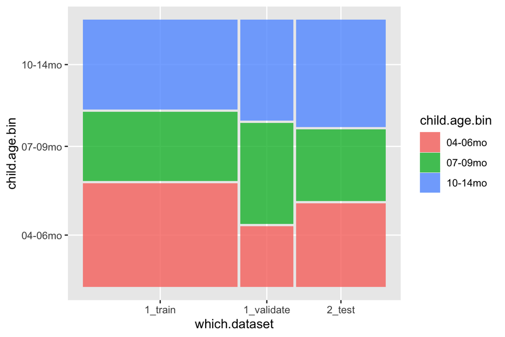

```r
# Plot
ggplot(participants_ML) +
  geom_mosaic(aes(x=product(which.dataset), fill=child.age.bin))
```

```r
#Counts
with(participants_ML, table(child.age.bin, which.dataset))
```

```
##              which.dataset
## child.age.bin 1_train 1_validate 2_test
##       04-06mo      15          3      7
##       07-09mo      10          5      6
##       10-14mo      13          5      9
```

```r
# Proportions
with(participants_ML, table(child.age.bin, which.dataset))%>%
  prop.table(margin=2)
```

```
##              which.dataset
## child.age.bin   1_train 1_validate    2_test
##       04-06mo 0.3947368  0.2307692 0.3181818
##       07-09mo 0.2631579  0.3846154 0.2727273
##       10-14mo 0.3421053  0.3846154 0.4090909
```

### Sex

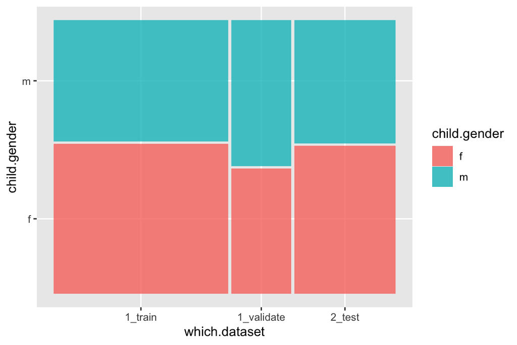

```r
# Plot
ggplot(participants_ML) +
  geom_mosaic(aes(x=product(which.dataset), fill=child.gender))
```

```r
# Counts
with(participants_ML, table(child.gender, which.dataset))
```

```
##             which.dataset
## child.gender 1_train 1_validate 2_test
##            f      21          6     12
##            m      17          7     10
```

```r
# Proportions
with(participants_ML, table(child.gender, which.dataset)) %>%
  prop.table(margin=2)
```

```
##             which.dataset
## child.gender   1_train 1_validate    2_test
##            f 0.5526316  0.4615385 0.5454545
##            m 0.4473684  0.5384615 0.4545455
```

### Race X gender

```r
# Proportions
with(participants_ML, table(parent.race.nonwhite, child.gender, which.dataset))%>%
  prop.table(margin='which.dataset') %>%
  addmargins(margin=c(1,2))
```

```
## , , which.dataset = 1_train
##
##                     child.gender
## parent.race.nonwhite          f          m        Sum
##   white only         0.39473684 0.34210526 0.73684211
##   reported non-white 0.15789474 0.10526316 0.26315789
##   Sum                0.55263158 0.44736842 1.00000000
##
## , , which.dataset = 1_validate
##
##                     child.gender
## parent.race.nonwhite          f          m        Sum
##   white only         0.38461538 0.46153846 0.84615385
##   reported non-white 0.07692308 0.07692308 0.15384615
##   Sum                0.46153846 0.53846154 1.00000000
##
## , , which.dataset = 2_test
##
##                     child.gender
## parent.race.nonwhite          f          m        Sum
##   white only         0.40909091 0.36363636 0.77272727
##   reported non-white 0.13636364 0.09090909 0.22727273
##   Sum                0.54545455 0.45454545 1.00000000
```

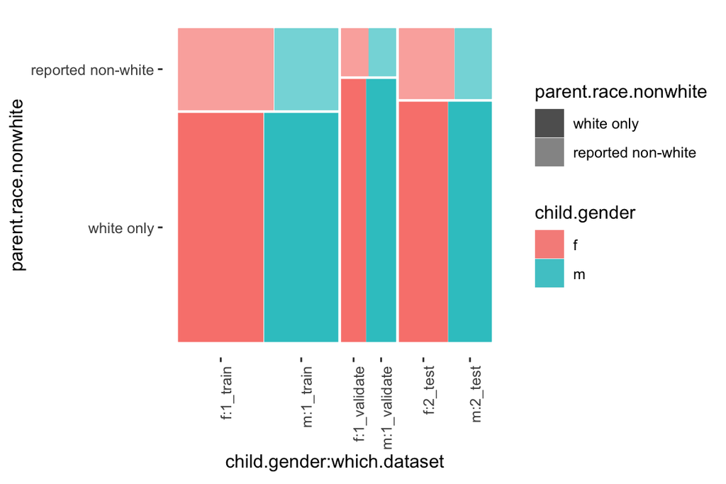

```r
# Plot
ggplot(participants_ML) +
  geom_mosaic(aes(x=product(parent.race.nonwhite, which.dataset),
                  fill=child.gender, alpha=parent.race.nonwhite)) +
  scale_alpha_manual(values=c(.9, .6)) +
      theme_mosaic()+
  theme(axis.text.x = element_text(angle = 90, hjust = 1))
```

### Age X gender

```r
with(participants_ML, table(child.age.bin, child.gender, which.dataset))%>%
  prop.table(margin='which.dataset') %>%
  addmargins(margin=c(1,2))
```

```
## , , which.dataset = 1_train
##
##              child.gender
## child.age.bin          f          m        Sum
##       04-06mo 0.28947368 0.10526316 0.39473684
##       07-09mo 0.15789474 0.10526316 0.26315789
##       10-14mo 0.10526316 0.23684211 0.34210526
##       Sum     0.55263158 0.44736842 1.00000000
##
## , , which.dataset = 1_validate
##
##              child.gender
## child.age.bin          f          m        Sum
##       04-06mo 0.15384615 0.07692308 0.23076923
##       07-09mo 0.15384615 0.23076923 0.38461538
##       10-14mo 0.15384615 0.23076923 0.38461538
##       Sum     0.46153846 0.53846154 1.00000000
##
## , , which.dataset = 2_test
##
##              child.gender
## child.age.bin          f          m        Sum
##       04-06mo 0.22727273 0.09090909 0.31818182
##       07-09mo 0.13636364 0.13636364 0.27272727
##       10-14mo 0.18181818 0.22727273 0.40909091
##       Sum     0.54545455 0.45454545 1.00000000
```

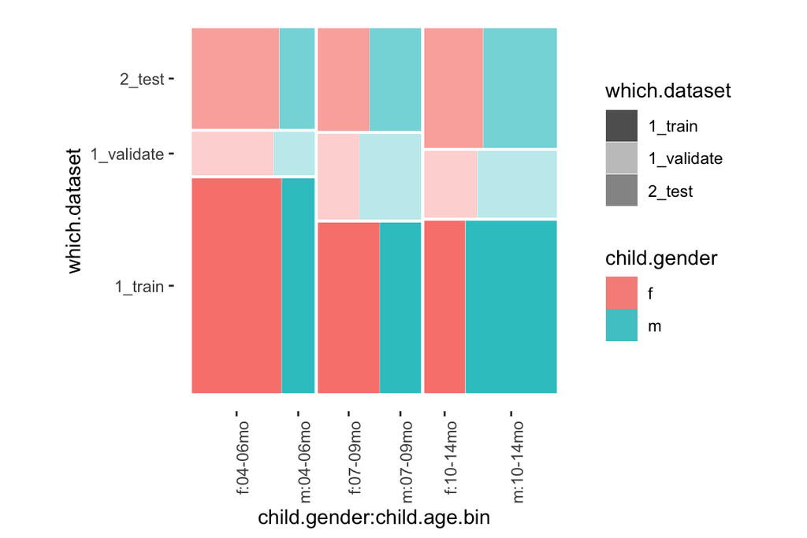

```r
# Plot
ggplot(participants_ML) +
  geom_mosaic(aes(x=product(which.dataset, child.age.bin),
                  fill=child.gender,alpha=which.dataset))+
  scale_alpha_manual(values =c(.9,.3, .6))+
      theme_mosaic()+
  theme(axis.text.x = element_text(angle = 90, hjust = 1))
```

### Age X race

```r
with(participants_ML, table(child.age.bin, parent.race.nonwhite, which.dataset))%>%
  prop.table(margin='which.dataset') %>%
  addmargins(margin=c(1,2))
```

```
## , , which.dataset = 1_train
##
##              parent.race.nonwhite
## child.age.bin white only reported non-white        Sum
##       04-06mo 0.31578947         0.07894737 0.39473684
##       07-09mo 0.15789474         0.10526316 0.26315789
##       10-14mo 0.26315789         0.07894737 0.34210526
##       Sum     0.73684211         0.26315789 1.00000000
##
## , , which.dataset = 1_validate
##
##              parent.race.nonwhite
## child.age.bin white only reported non-white        Sum
##       04-06mo 0.15384615         0.07692308 0.23076923
##       07-09mo 0.38461538         0.00000000 0.38461538
##       10-14mo 0.30769231         0.07692308 0.38461538
##       Sum     0.84615385         0.15384615 1.00000000
##
## , , which.dataset = 2_test
##
##              parent.race.nonwhite
## child.age.bin white only reported non-white        Sum
##       04-06mo 0.22727273         0.09090909 0.31818182
##       07-09mo 0.22727273         0.04545455 0.27272727
##       10-14mo 0.31818182         0.09090909 0.40909091
##       Sum     0.77272727         0.22727273 1.00000000
```

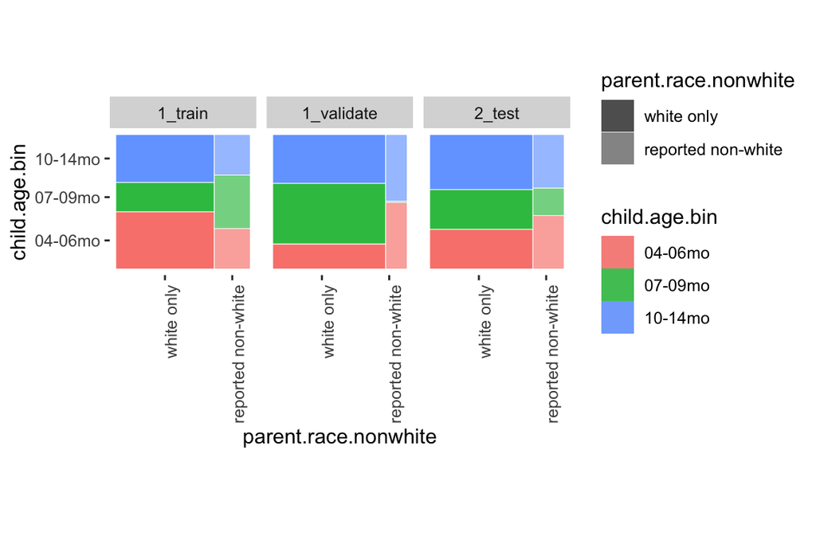

```r
# Plot
ggplot(participants_ML) +
  geom_mosaic(aes(x=product(child.age.bin,parent.race.nonwhite),
                  alpha=parent.race.nonwhite, fill=child.age.bin))+
  facet_wrap(.~which.dataset)+
  scale_alpha_manual(values =c(.9,.6))+
      theme_mosaic()+
  theme(axis.text.x = element_text(angle = 90, hjust = 1))
```

# Export split as tsv

```r
participants_ML %>% rename(studyID = studyid) %>%
  write_csv("../ForQI/prefphys_split0_participants.tsv")

videos %>% left_join(select(participants_ML, studyid, childID, which.dataset),
                     by=c(studyID="studyid",childID="childID")) %>%
  filter(!is.na(which.dataset)) %>%
  write_csv("../ForQI/prefphys_split0_videos.tsv")
```